# 8. Instrumental variable analysis

2023-03-13

> [*Back to content page*](https://flatter11.github.io/r.studio/)

Learning objectives

- Estimate treatment effect using instrumental variable analysis for noncontrolled experiment
- Understand the **assumptions** of instrumental variable analysis
- **Interpret** results from instrumental variable analysis

# Instrumental variable analysis

- Deal with **hidden confounding**. Ordinary regression and propensity score methods: only deal with observed confounders
  - Consider outcome Y<sub>i</sub> = αC<sub>i</sub> + βX<sub>i</sub> + e<sub>i</sub>
  - If there are hidden confounders, cov(X, e) ≠ 0
  - This violate key assumptions of ordinary least square (OLS) (under linear regression) to estimate β
- 3 assumptions
  1. Associated with exposure X: cov(Z, X) ≠ 0
  2. Uncorrelated with confounder C
  3. All effects of the IV on outcome mediated through the treatment only
- Example of IV
  1. Is smoking (exposure) associated with health (outcome)? IV: tobacco tax
  2. Is blood pressure (exposure) associated with cardiovascular disease (outcome)? IV: genetic

##### Example: BMI

- Are adolescents BMI (outcome) affected by close friends’ BMI (exposure)?
- Instrumental variable: BMI of parents of close friends

```r
bmi <- read.csv("Folder/examplebmiiva.csv")
```

## Preliminary analysis

As a preliminary analysis, fit a linear regression to explain adolescents BMI by close friend’s BMI

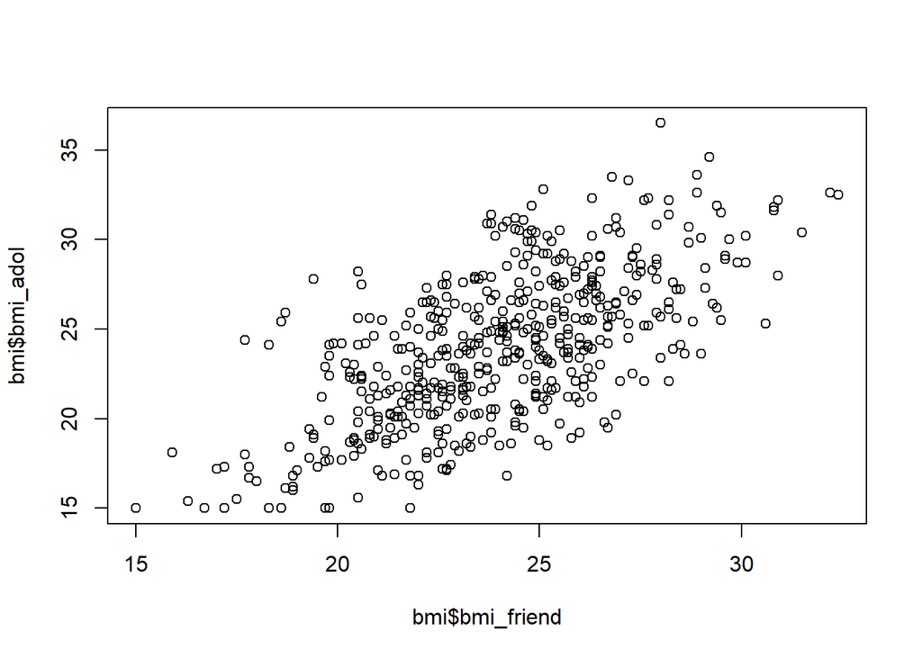

```r
plot(bmi$bmi_friend, bmi$bmi_adol) #Scatter plot to see when friends' BMI increase, adolescent's bmi increase
```

```r
summary(lm(bmi_adol ~ bmi_friend, data=bmi)) #Beta = 0.93: an increase of 1 kg/m2 in close friend’s
#average BMI is associated with 0.93 kg/m2 increase of an adolescent’s BMI.
#NOTE: this result not adjusted for measured/unmeasured confounders --> need IV analysis
```

```
##
## Call:
## lm(formula = bmi_adol ~ bmi_friend, data = bmi)
##
## Residuals:
##     Min      1Q  Median      3Q     Max
## -7.3413 -2.1607 -0.2833  2.1746  8.8179
##
## Coefficients:
##             Estimate Std. Error t value Pr(>|t|)
## (Intercept)   1.5919     1.1894   1.338    0.181
## bmi_friend    0.9318     0.0492  18.940   <2e-16 ***
## ---
## Signif. codes:  0 '***' 0.001 '**' 0.01 '*' 0.05 '.' 0.1 ' ' 1
##
## Residual standard error: 3.207 on 498 degrees of freedom
## Multiple R-squared:  0.4187, Adjusted R-squared:  0.4176
## F-statistic: 358.7 on 1 and 498 DF,  p-value: < 2.2e-16
```

## 1.1 Wald estimator

- Wald estimator: β<sub>XY</sub> = β<sub>ZY</sub> / β<sub>ZX</sub>
- Use Fieller’s theorem to estimate the standard error of the effect estimate

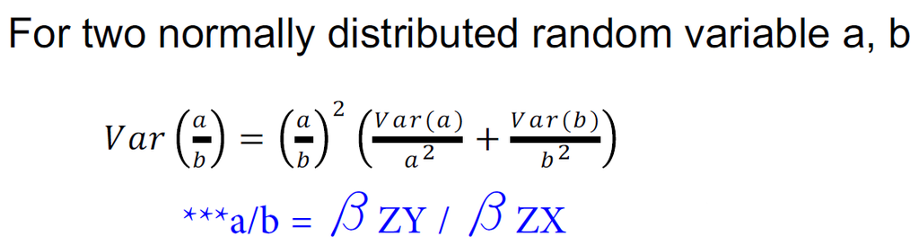

```r
## Estimate with βXY = βZY / βZX
#βZY and βZX
bmi.zy <- lm(bmi_adol~bmi_parent, data=bmi) #beta = 0.344
bmi.zx <- lm(bmi_friend~bmi_parent, data=bmi) #beta = 0.339
#βXY
b.zy <- coef(bmi.zy)[2]
b.zx <- coef(bmi.zx)[2]
b.zy/b.zx #The estimated effect of friend's BMI on adolescent BMI beta_xy: 1.017

## Variance with Fieller's theorem
var.zy <- vcov(bmi.zy)[2,2] #variance (covariance where both x and y are x)
var.zx <- vcov(bmi.zx)[2,2]
(b.zy/b.zx)^2 * (var.zy/b.zy^2 + var.zx/b.zx^2)
```

```
## bmi_parent
##   1.017007
## bmi_parent
## 0.01490696
```